# Tugas Praktikum 4 MPDW

David Fauzan Akmal

2024-09-16

## Proses MA

Proses MA dapat dituliskan sebagai berikut:

$$y_{t} = e_t - \theta_{1}e_{t-1} - \theta_{2}e_{t-2} - \dots -
\theta_{q}e_{t-q}$$
Terlihat bahwa $e_t$, atau *white noise*, berperan penting dalam pembangkitan proses MA.

## Pembangkitan White Noise

```r
set.seed(032)
wn <- rnorm(300)
ma2 = wn[c(1,2)]
```

## MA (2) dengan θ1 = 0.4 dan θ2 = 0.6

$$y_t = e_t-0.4e_{t-1}-0.6e_{t-2}$$

```r
for(i in 3:300){
   ma2[i] <- wn[i] - 0.4 * wn[i - 1] - 0.6 * wn[i - 2]
}
ma2
```

```
##   [1]  0.014640541  0.873288708 -1.386046010  0.572869883  0.791938852
##   [6] -0.184155930 -0.147737876 -0.982412523  0.918540947  0.350002424
##  [11] -0.153051812 -0.476958942 -0.041603551 -0.115452676  0.015768027
##  [16] -0.251860198  1.393208404 -0.523921098 -0.699295711  0.901687010
##  [21] -0.654243434 -1.468618639  1.547758528  0.635911174  0.032407308
##  [26]  0.369290146 -0.268297379 -2.790917755  1.485096831  1.310788645
##  [31]  0.041738032 -0.022262438 -1.540250402  0.990974521  1.631576562
##  [36] -0.249031263 -1.443598527 -1.755671551  1.217313957  0.156960677
##  [41] -0.194056127  0.234231938 -1.008525155  0.201175981 -0.270915962
##  [46] -1.179492909  0.016239687  0.806019498  0.293145152 -0.622373159
##  [51]  1.259973957  0.404306581 -0.619656576  0.242805284 -1.219402678
##  [56] -0.089096635  1.982887833 -0.053783939  0.495802340 -0.839494376
##  [61] -1.307795112 -1.312498893  1.143996078  1.583764944  0.218229577
##  [66] -1.111023600 -0.489453168  1.280263224  0.700613561 -0.439325839
##  [71] -1.340167923  0.789033356  0.896455476 -0.848539459 -0.881589598
```

[output cut: 45 more lines]

Selain menggunakan cara di atas, pembangkitan proses MA(2) dapat dilakukan dengan fungsi `arima.sim()` sebagai berikut.

```r
set.seed(032)
ma2.1 <- arima.sim(list(order=c(0,0,2), ma=c(0.4,0.6)), n=300)
ma2.1
```

```
## Time Series:
## Start = 1
## End = 300
## Frequency = 1
##   [1] -0.66984639  0.79845937  0.10693511  0.99819121  0.71720061 -0.26620626
##   [7]  0.76077107  0.27255596  1.10355876  0.27677887  0.44862859 -0.07275071
##  [13]  0.18470169 -0.28459434  1.29890842  0.23105291  0.79882711  0.76577866
##  [19]  0.07246167 -0.70085194  0.33090124  0.08569273  1.44824473  1.39451330
##  [25]  1.32561522 -1.30970855  0.47923701 -0.36385360  1.59911236  1.20223874
##  [31] -0.08374965  1.04936029  1.47331046  2.21712443  1.20657095 -0.66962668
##  [37]  0.10497812 -0.76930144  0.35438281 -0.06904184 -0.84625311 -0.44162127
##  [43] -1.47996103 -2.02411088 -2.31572802 -2.03593811 -1.57851529 -1.87447238
##  [49] -0.50998634 -0.79380570 -0.32546366 -0.36894228 -1.83692961 -1.38731175
##  [55] -0.44147490 -0.32306379  1.26991101 -0.35931768 -0.72789192 -2.84606094
##  [61] -1.74084008 -1.15010855  0.03358573 -0.75010364 -1.08281488 -0.46532034
```

[output cut: 39 more lines]

## Karakteristik MA(2)

### Plot Time Series

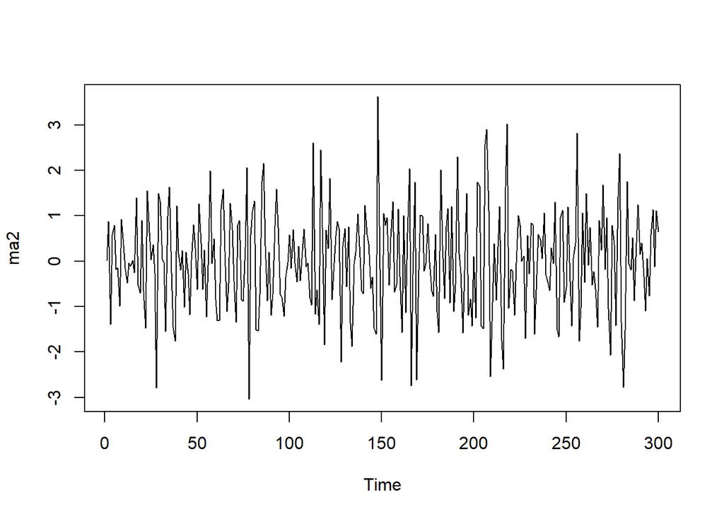

```r
ts.plot(ma2)
```

Berdasarkan plot time series, terlihat bahwa data MA(2) yang dibangkitkan stasioner dalam rataan

### Plot ACF

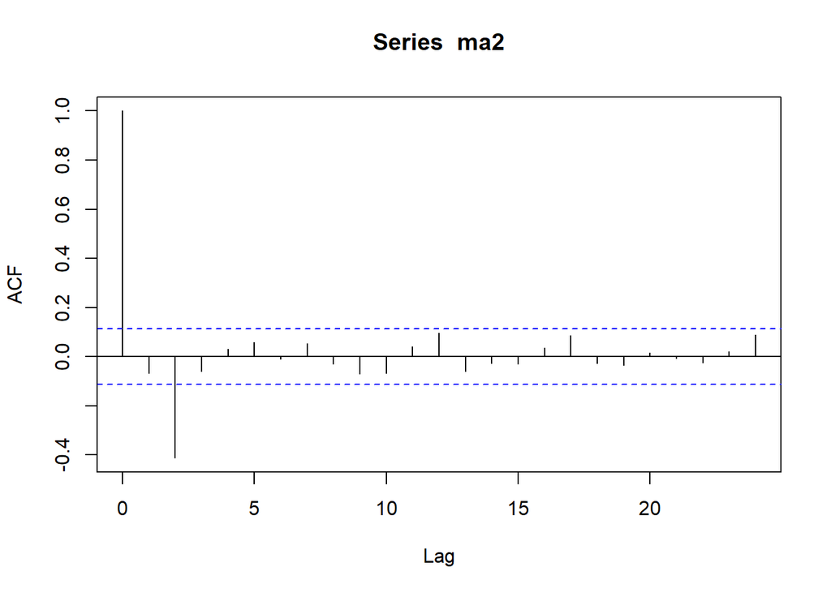

```r
acf(ma2)
```

Berdasarkan plot AFC tersebut, terlihat bahwa plot ACF *cuts off* di lag kedua

### Plot PACF

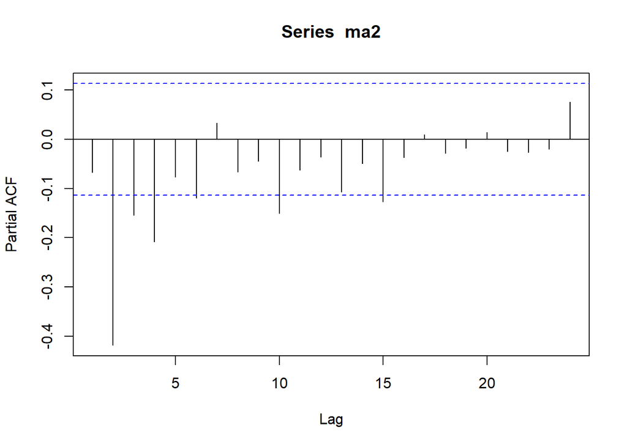

```r
pacf(ma2)
```

Berdasarkan plot PACF tersebut, terlihat bahwa plot PACF cenderung *tails off*

### Plot EACF

```r
TSA::eacf(ma2)
```

```
## AR/MA
##   0 1 2 3 4 5 6 7 8 9 10 11 12 13
## 0 o x o o o o o o o o o  o  o  o
## 1 x x x o o o o o o o o  o  o  o
## 2 x x x x o o o o o o o  o  o  o
## 3 x x o o o o o o o o o  o  o  o
## 4 x x o o o x o o o o o  o  o  o
## 5 x x x x o o o o o o o  o  o  o
## 6 x x x x x o o x o o o  o  o  o
## 7 x x o x o o o o x o o  o  o  o
```

Berdasarkan pola segitiga nol pada plot EACF, terlihat bahwa segitiga nol berada pada ordo AR(0) dan ordo MA(2)

### Scatterplot Antar Lag

#### Korelasi antara $Y_t$ dengan $Y_{t-1}$

```r
#Yt
yt_ma2 <- ma2[-1]
yt_ma2
```

```
##   [1]  0.873288708 -1.386046010  0.572869883  0.791938852 -0.184155930
##   [6] -0.147737876 -0.982412523  0.918540947  0.350002424 -0.153051812
##  [11] -0.476958942 -0.041603551 -0.115452676  0.015768027 -0.251860198
##  [16]  1.393208404 -0.523921098 -0.699295711  0.901687010 -0.654243434
##  [21] -1.468618639  1.547758528  0.635911174  0.032407308  0.369290146
##  [26] -0.268297379 -2.790917755  1.485096831  1.310788645  0.041738032
##  [31] -0.022262438 -1.540250402  0.990974521  1.631576562 -0.249031263
##  [36] -1.443598527 -1.755671551  1.217313957  0.156960677 -0.194056127
##  [41]  0.234231938 -1.008525155  0.201175981 -0.270915962 -1.179492909
##  [46]  0.016239687  0.806019498  0.293145152 -0.622373159  1.259973957
##  [51]  0.404306581 -0.619656576  0.242805284 -1.219402678 -0.089096635
##  [56]  1.982887833 -0.053783939  0.495802340 -0.839494376 -1.307795112
##  [61] -1.312498893  1.143996078  1.583764944  0.218229577 -1.111023600
##  [66] -0.489453168  1.280263224  0.700613561 -0.439325839 -1.340167923
##  [71]  0.789033356  0.896455476 -0.848539459 -0.881589598  0.304667112
```

[output cut: 45 more lines]

```r
#Yt-1
yt_1_ma2 <- ma2[-300]
yt_1_ma2
```

```
##   [1]  0.014640541  0.873288708 -1.386046010  0.572869883  0.791938852
##   [6] -0.184155930 -0.147737876 -0.982412523  0.918540947  0.350002424
##  [11] -0.153051812 -0.476958942 -0.041603551 -0.115452676  0.015768027
##  [16] -0.251860198  1.393208404 -0.523921098 -0.699295711  0.901687010
##  [21] -0.654243434 -1.468618639  1.547758528  0.635911174  0.032407308
##  [26]  0.369290146 -0.268297379 -2.790917755  1.485096831  1.310788645
##  [31]  0.041738032 -0.022262438 -1.540250402  0.990974521  1.631576562
##  [36] -0.249031263 -1.443598527 -1.755671551  1.217313957  0.156960677
##  [41] -0.194056127  0.234231938 -1.008525155  0.201175981 -0.270915962
##  [46] -1.179492909  0.016239687  0.806019498  0.293145152 -0.622373159
##  [51]  1.259973957  0.404306581 -0.619656576  0.242805284 -1.219402678
##  [56] -0.089096635  1.982887833 -0.053783939  0.495802340 -0.839494376
##  [61] -1.307795112 -1.312498893  1.143996078  1.583764944  0.218229577
##  [66] -1.111023600 -0.489453168  1.280263224  0.700613561 -0.439325839
##  [71] -1.340167923  0.789033356  0.896455476 -0.848539459 -0.881589598
```

[output cut: 45 more lines]

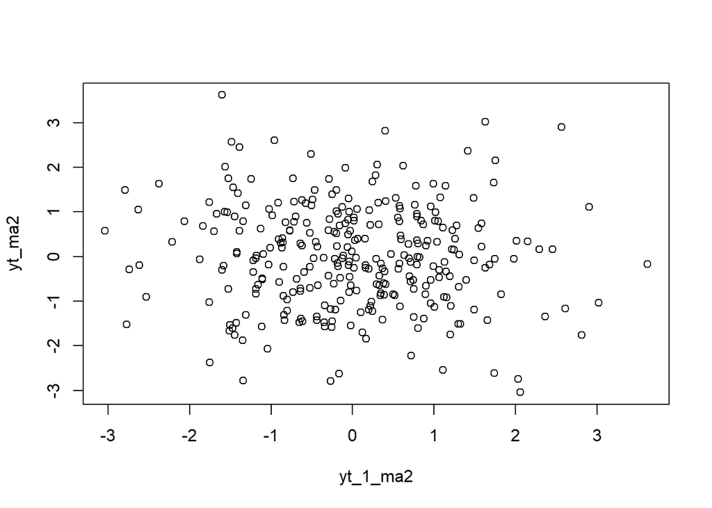

```r
plot(y=yt_ma2,x=yt_1_ma2)
```

```r
cor(yt_ma2,yt_1_ma2)
```

```
## [1] -0.06737415
```

Sementara korelasi antara $Y_t$ dengan $Y_{t-1}$ dari hasil perhitungan teoritis yaitu

$$\rho_1=\frac{-\theta_1 +\theta_1\theta_2}{1+\theta_1^2 +\theta_2^2
}=\frac{-0.4+(0.4)(0.6)}{1+0.4^2+0.6^2}=-0.105$$

#### Korelasi antara $Y_t$ dengan $Y_{t-2}$

```r
#Yt
yt_ma2 <- ma2[-c(1,2)]

#Yt-2
yt_2_ma <- ma2[-c(199,200)]
```

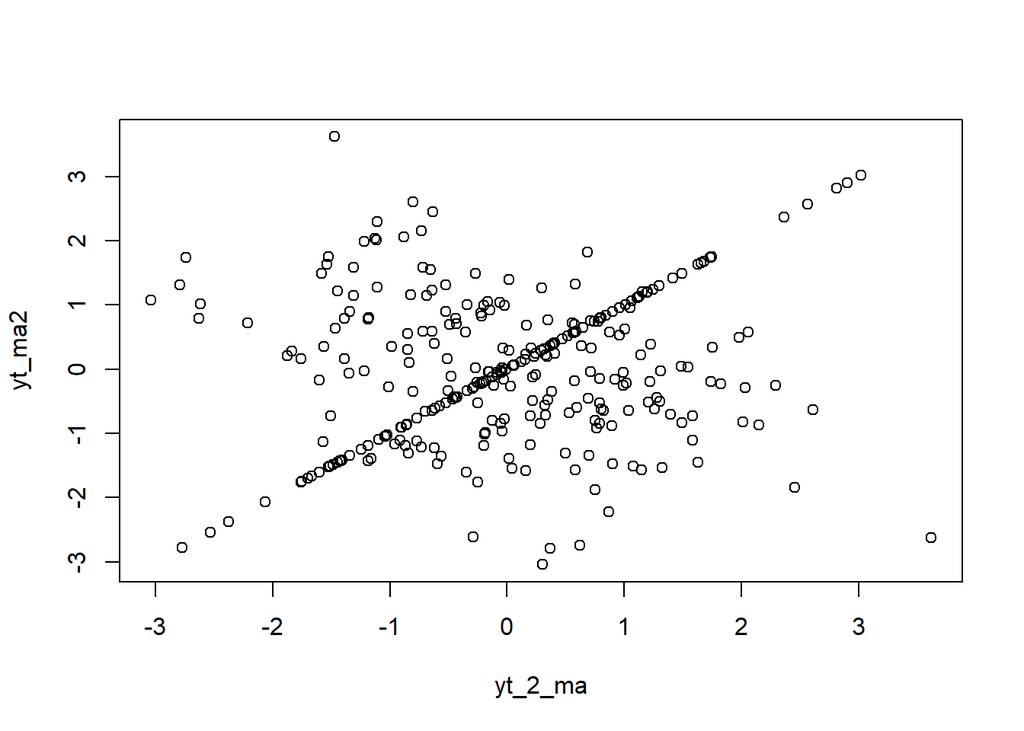

```r
plot(y=yt_ma2,x=yt_2_ma)
```

```r
cor(yt_ma2,yt_2_ma)
```

```
## [1] 0.1326038
```

Sementara hasil perhitungan teoritis sebagai berikut:
$$\rho_1=\frac{-\theta_2}{1+\theta_1^2 +\theta_2^2
}=\frac{-0.6}{1+0.4^2+0.6^2}=-0.394$$
#### Korelasi antara $Y_t$ dengan $Y_{t-3}$

```r
#Yt
yt_ma3<- ma2[-c(1,2,3)]
#Yt-3
yt_3_ma <- ma2[-c(288,299,300)]
```

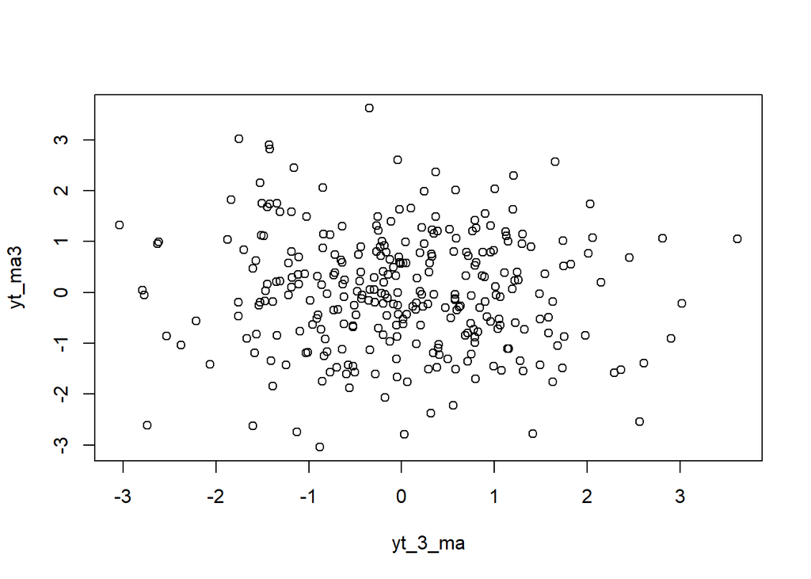

```r
plot(y=yt_ma3,x=yt_3_ma)
```

```r
cor(yt_ma3,yt_3_ma)
```

```
## [1] -0.05844091
```

Berdasarkan teoritis, seharusnya korelasi antara $Y_t$ dengan $Y_{t-3}$ bernilai 0.

## Proses AR

Proses AR dapat dituliskan sebagai berikut:

$$y_{t} = c + e_t + \phi_{1}Y_{t-1} +
\phi_{2}Y_{t-2} + \dots + \phi_{q}Y_{t-q} = c+{e_t+\sum_{i=1}^p
\phi_iY_{t-i}}$$
Terlihat bahwa $Y_t$ berperan penting dalam pembangkitan proses AR.

```r
set.seed(032)
wn = rnorm(300)
n <- length(wn)
n
```

```
## [1] 300
```

```r
ar2 <- c(1:n)
for (i in 3:n) {ar2[i]<-wn[i]+0.5*ar2[i-1]+0.2*ar2[i-2]}
ar2
```

```
##   [1]  1.00000000  2.00000000  0.17205380  1.17169153  1.06969350  1.17620270
##   [7]  1.08677142  0.15431685  1.13416872  0.90922692  1.15670068  0.66010569
##  [13]  0.76490550  0.42037219  0.46340206  0.04754820  1.46251292  0.59433201
##  [19]  0.63943429  1.27231638  0.47315417 -0.59369493  0.73711325  0.61061959
##  [25]  1.19305846  1.60055487  1.56754805 -0.94642815  0.82246246  0.69541312
##  [31]  1.33262425  1.39538290  0.15221628  1.37535212  2.27056282  2.39439842
##  [37]  1.53279798  0.03262956  0.98402041  0.19236574  0.37315029  0.30764334
##  [43] -0.69893740 -0.40816267 -1.21930731 -2.29308808 -2.54014967 -2.34365176
##  [49] -2.32254089 -2.87842357 -1.52872615 -1.53479735 -1.54570402 -1.14287998
##  [55] -2.40874694 -2.17115366 -0.79661975 -1.02096447  0.21305049 -0.69707368
##  [61] -1.32377026 -2.88057978 -2.00346594 -1.36102073 -0.95529590 -1.68041572
##  [67] -1.81740106 -0.83731223 -0.39021460 -0.40064403 -1.39860954 -0.46134263
##  [73] -0.15884813 -0.68875945 -1.25363863 -1.12113992  0.57990018 -2.63131932
##  [79] -0.86222575 -1.36456117  0.50541721 -1.22390486 -1.70286414 -3.02362369
##  [85] -1.58856329 -0.30181481  0.46844595  0.34160238  1.09018864 -0.14286488
```

[output cut: 35 more lines]

Selain menggunakan cara di atas, pembangkitan proses AR dapat dilakukan dengan fungsi `arima.sim()` sebagai berikut.

```r
set.seed(032)
ar2.1 <- arima.sim(list(order=c(2,0,0), ar=c(0.5,0.2)), n=300)
ar2.1
```

```
## Time Series:
## Start = 1
## End = 300
## Frequency = 1
##   [1]  1.59903276  1.56638767 -0.94731277  0.82178807  0.69489901  1.33223231
##   [7]  1.39508411  0.15198849  1.37517847  2.27043044  2.39429750  1.53272105
##  [13]  0.03257091  0.98397570  0.19233165  0.37312431  0.30762353 -0.69895250
##  [19] -0.40817419 -1.21931609 -2.29309478 -2.54015477 -2.34365565 -2.32254385
##  [25] -2.87842583 -1.52872788 -1.53479866 -1.54570502 -1.14288074 -2.40874752
##  [31] -2.17115410 -0.79662009 -1.02096473  0.21305029 -0.69707383 -1.32377037
##  [37] -2.88057987 -2.00346601 -1.36102078 -0.95529594 -1.68041575 -1.81740108
##  [43] -0.83731225 -0.39021462 -0.40064404 -1.39860955 -0.46134264 -0.15884813
##  [49] -0.68875945 -1.25363864 -1.12113992  0.57990018 -2.63131932 -0.86222575
##  [55] -1.36456117  0.50541721 -1.22390486 -1.70286414 -3.02362369 -1.58856329
##  [61] -0.30181481  0.46844595  0.34160238  1.09018864 -0.14286488 -0.38147663
```

[output cut: 39 more lines]

### Plot Time Series

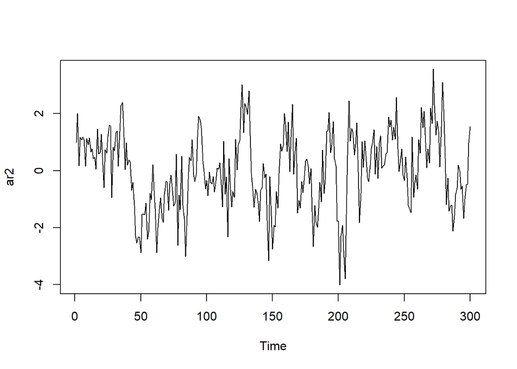

```r
ts.plot(ar2)
```

Berdasarkan plot time series tersebut terlihat bahwa data cenderung stasioner pada rataan

### Plot ACF

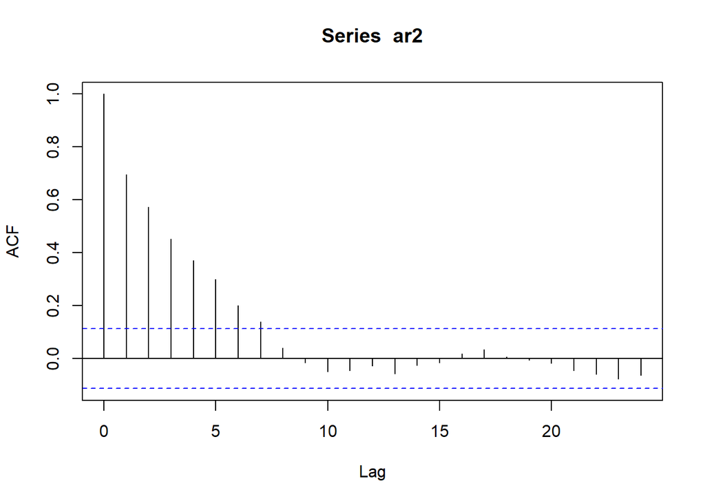

```r
acf(ar2)
```

### Plot PACF

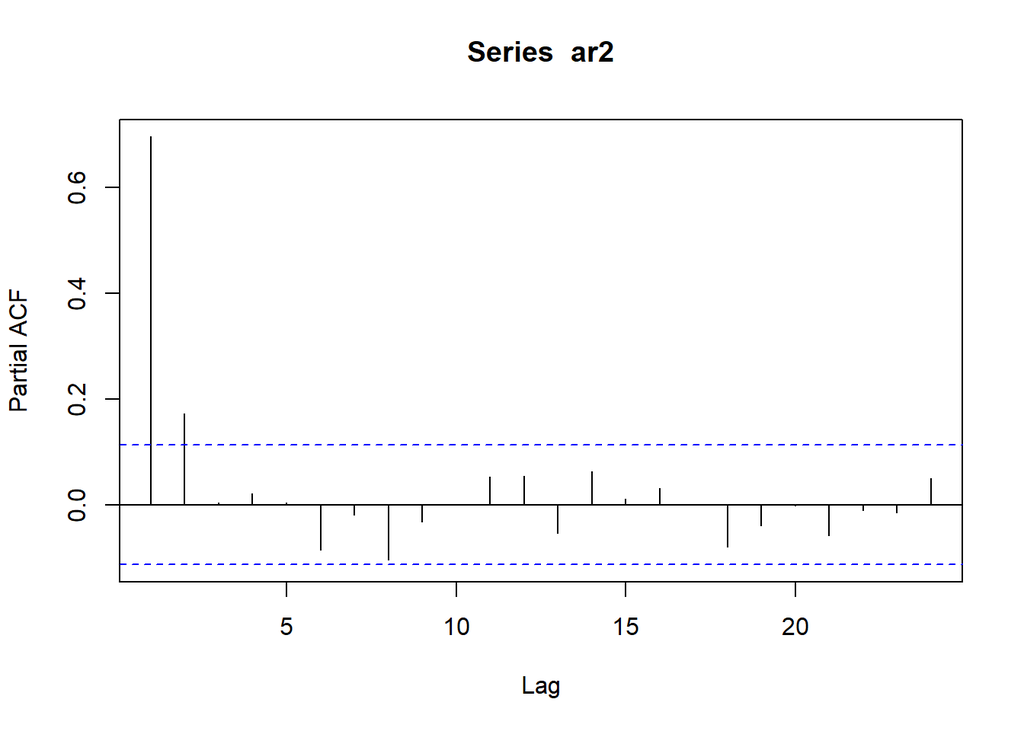

```r
pacf(ar2)
```

### Plot EACF

```r
TSA::eacf(ar2)
```

```
## AR/MA
##   0 1 2 3 4 5 6 7 8 9 10 11 12 13
## 0 x x x x x x x o o o o  o  o  o
## 1 x o o o o o x o o o o  o  o  o
## 2 o o o o o o x o o o o  o  o  o
## 3 x o o o o o o o o o o  o  o  o
## 4 x x o o o o o o o o o  o  o  o
## 5 o x o x o o o o o o o  x  o  o
## 6 x x o x o o o o o o o  o  o  o
## 7 x x o x o x o o o o o  o  o  o
```

Berdasarkan pola segitiga nol pada plot EACF, terlihat bahwa segitiga nol berada pada ordo AR(2) dan ordo MA(0)

### Scatterplot Antar Lag

#### Korelasi antara $Y_t$ dengan $Y_{t-1}$

```r
#Yt
yt_ar <- ar2[-1]
yt_ar
```

```
##   [1]  2.00000000  0.17205380  1.17169153  1.06969350  1.17620270  1.08677142
##   [7]  0.15431685  1.13416872  0.90922692  1.15670068  0.66010569  0.76490550
##  [13]  0.42037219  0.46340206  0.04754820  1.46251292  0.59433201  0.63943429
##  [19]  1.27231638  0.47315417 -0.59369493  0.73711325  0.61061959  1.19305846
##  [25]  1.60055487  1.56754805 -0.94642815  0.82246246  0.69541312  1.33262425
##  [31]  1.39538290  0.15221628  1.37535212  2.27056282  2.39439842  1.53279798
##  [37]  0.03262956  0.98402041  0.19236574  0.37315029  0.30764334 -0.69893740
##  [43] -0.40816267 -1.21930731 -2.29308808 -2.54014967 -2.34365176 -2.32254089
##  [49] -2.87842357 -1.52872615 -1.53479735 -1.54570402 -1.14287998 -2.40874694
##  [55] -2.17115366 -0.79661975 -1.02096447  0.21305049 -0.69707368 -1.32377026
##  [61] -2.88057978 -2.00346594 -1.36102073 -0.95529590 -1.68041572 -1.81740106
##  [67] -0.83731223 -0.39021460 -0.40064403 -1.39860954 -0.46134263 -0.15884813
##  [73] -0.68875945 -1.25363863 -1.12113992  0.57990018 -2.63131932 -0.86222575
##  [79] -1.36456117  0.50541721 -1.22390486 -1.70286414 -3.02362369 -1.58856329
##  [85] -0.30181481  0.46844595  0.34160238  1.09018864 -0.14286488 -0.38147663
```

[output cut: 35 more lines]

```r
#Yt-1
yt_1_ar <- ar2[-200]
yt_1_ar
```

```
##   [1]  1.00000000  2.00000000  0.17205380  1.17169153  1.06969350  1.17620270
##   [7]  1.08677142  0.15431685  1.13416872  0.90922692  1.15670068  0.66010569
##  [13]  0.76490550  0.42037219  0.46340206  0.04754820  1.46251292  0.59433201
##  [19]  0.63943429  1.27231638  0.47315417 -0.59369493  0.73711325  0.61061959
##  [25]  1.19305846  1.60055487  1.56754805 -0.94642815  0.82246246  0.69541312
##  [31]  1.33262425  1.39538290  0.15221628  1.37535212  2.27056282  2.39439842
##  [37]  1.53279798  0.03262956  0.98402041  0.19236574  0.37315029  0.30764334
##  [43] -0.69893740 -0.40816267 -1.21930731 -2.29308808 -2.54014967 -2.34365176
##  [49] -2.32254089 -2.87842357 -1.52872615 -1.53479735 -1.54570402 -1.14287998
##  [55] -2.40874694 -2.17115366 -0.79661975 -1.02096447  0.21305049 -0.69707368
##  [61] -1.32377026 -2.88057978 -2.00346594 -1.36102073 -0.95529590 -1.68041572
##  [67] -1.81740106 -0.83731223 -0.39021460 -0.40064403 -1.39860954 -0.46134263
##  [73] -0.15884813 -0.68875945 -1.25363863 -1.12113992  0.57990018 -2.63131932
##  [79] -0.86222575 -1.36456117  0.50541721 -1.22390486 -1.70286414 -3.02362369
##  [85] -1.58856329 -0.30181481  0.46844595  0.34160238  1.09018864 -0.14286488
```

[output cut: 35 more lines]

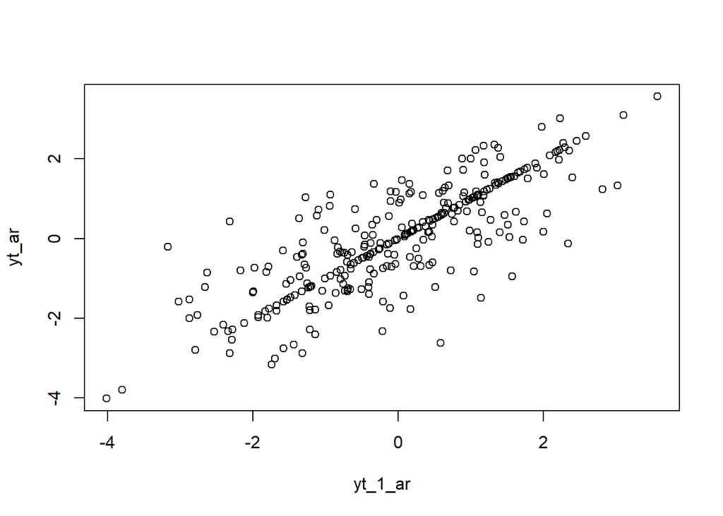

```r
plot(y=yt_ar,x=yt_1_ar)
```

Berdasarkan scatterplot tersebut, terlihat bahwa terdapat hubungan positif antara $Y_t$ dengan $Y_{t-1}$. Hal ini sesuai dengan teori yang ada

```r
cor(yt_ar,yt_1_ar)
```

```
## [1] 0.804489
```

Korelasi antara $Y_t$ dengan $Y_{t-1}$ dari hasil simulasi lumayan mendekati perhitungan teoritis yaitu $\rho_1=\phi_1/(1-\phi_2)=0.5/(1-0.2)=0.625$

#### Korelasi antara $Y_t$ dengan $Y_{t-2}$

```r
#Yt
yt_ar2 <- ar2[-c(1,2)]
yt_ar2
```

```
##   [1]  0.17205380  1.17169153  1.06969350  1.17620270  1.08677142  0.15431685
##   [7]  1.13416872  0.90922692  1.15670068  0.66010569  0.76490550  0.42037219
##  [13]  0.46340206  0.04754820  1.46251292  0.59433201  0.63943429  1.27231638
##  [19]  0.47315417 -0.59369493  0.73711325  0.61061959  1.19305846  1.60055487
##  [25]  1.56754805 -0.94642815  0.82246246  0.69541312  1.33262425  1.39538290
##  [31]  0.15221628  1.37535212  2.27056282  2.39439842  1.53279798  0.03262956
##  [37]  0.98402041  0.19236574  0.37315029  0.30764334 -0.69893740 -0.40816267
##  [43] -1.21930731 -2.29308808 -2.54014967 -2.34365176 -2.32254089 -2.87842357
##  [49] -1.52872615 -1.53479735 -1.54570402 -1.14287998 -2.40874694 -2.17115366
##  [55] -0.79661975 -1.02096447  0.21305049 -0.69707368 -1.32377026 -2.88057978
##  [61] -2.00346594 -1.36102073 -0.95529590 -1.68041572 -1.81740106 -0.83731223
##  [67] -0.39021460 -0.40064403 -1.39860954 -0.46134263 -0.15884813 -0.68875945
##  [73] -1.25363863 -1.12113992  0.57990018 -2.63131932 -0.86222575 -1.36456117
##  [79]  0.50541721 -1.22390486 -1.70286414 -3.02362369 -1.58856329 -0.30181481
##  [85]  0.46844595  0.34160238  1.09018864 -0.14286488 -0.38147663 -0.10708289
```

[output cut: 35 more lines]

```r
#Yt-2
yt_2_ar <- ar2[-c(199,200)]
yt_2_ar
```

```
##   [1]  1.00000000  2.00000000  0.17205380  1.17169153  1.06969350  1.17620270
##   [7]  1.08677142  0.15431685  1.13416872  0.90922692  1.15670068  0.66010569
##  [13]  0.76490550  0.42037219  0.46340206  0.04754820  1.46251292  0.59433201
##  [19]  0.63943429  1.27231638  0.47315417 -0.59369493  0.73711325  0.61061959
##  [25]  1.19305846  1.60055487  1.56754805 -0.94642815  0.82246246  0.69541312
##  [31]  1.33262425  1.39538290  0.15221628  1.37535212  2.27056282  2.39439842
##  [37]  1.53279798  0.03262956  0.98402041  0.19236574  0.37315029  0.30764334
##  [43] -0.69893740 -0.40816267 -1.21930731 -2.29308808 -2.54014967 -2.34365176
##  [49] -2.32254089 -2.87842357 -1.52872615 -1.53479735 -1.54570402 -1.14287998
##  [55] -2.40874694 -2.17115366 -0.79661975 -1.02096447  0.21305049 -0.69707368
##  [61] -1.32377026 -2.88057978 -2.00346594 -1.36102073 -0.95529590 -1.68041572
##  [67] -1.81740106 -0.83731223 -0.39021460 -0.40064403 -1.39860954 -0.46134263
##  [73] -0.15884813 -0.68875945 -1.25363863 -1.12113992  0.57990018 -2.63131932
##  [79] -0.86222575 -1.36456117  0.50541721 -1.22390486 -1.70286414 -3.02362369
##  [85] -1.58856329 -0.30181481  0.46844595  0.34160238  1.09018864 -0.14286488
```

[output cut: 35 more lines]

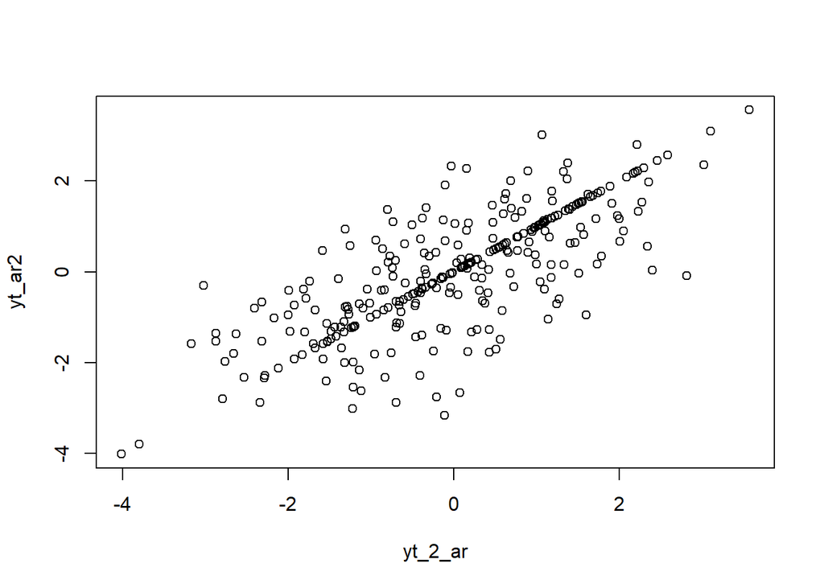

```r
plot(y=yt_ar2,x=yt_2_ar)
```

Berdasarkan scatterplot tersebut, terlihat bahwa terdapat hubungan positif antara $Y_t$ dengan $Y_{t-2}$. Hal ini sesuai dengan teori yang ada

```r
cor(yt_ar2,yt_2_ar)
```

```
## [1] 0.7484351
```